# Proyecto Final AEM

# REGRESIÓN LINEAL MÚLTIPLE CON GRADIENTE DESCENDIENTE:

```r
# NUESTROS REGRESORES A UTILIZAR PARA CONSTRUIR EL MODELO:

X1 <- S[, 1]
X2 <- S[, 2]
X3 <- S[, 3]
```

ANÁLISIS DESCRIPTIVO PREVIO DE LA VARIABLE RESPUESTA Y LOS REGRESORES ANTES DE CREAR EL MODELO:

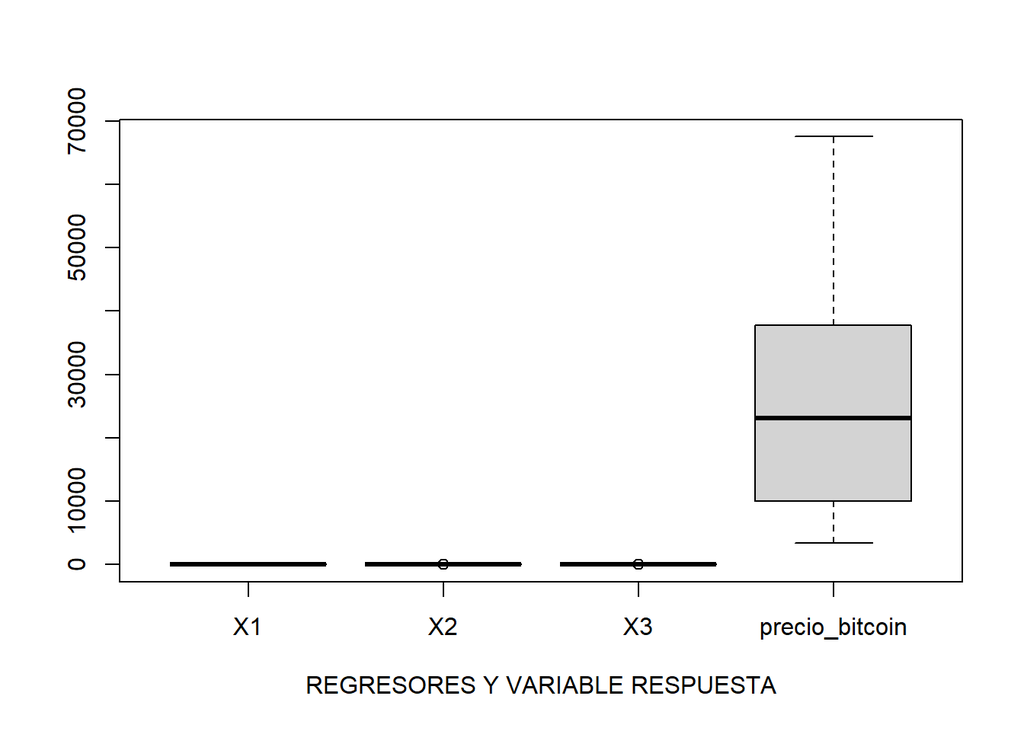

```r
#Diagramas de caja de bigotes:
datos_regresion <- data.frame(X1, X2, X3, precio_bitcoin)
boxplot(datos_regresion, xlab = "REGRESORES Y VARIABLE RESPUESTA")
```

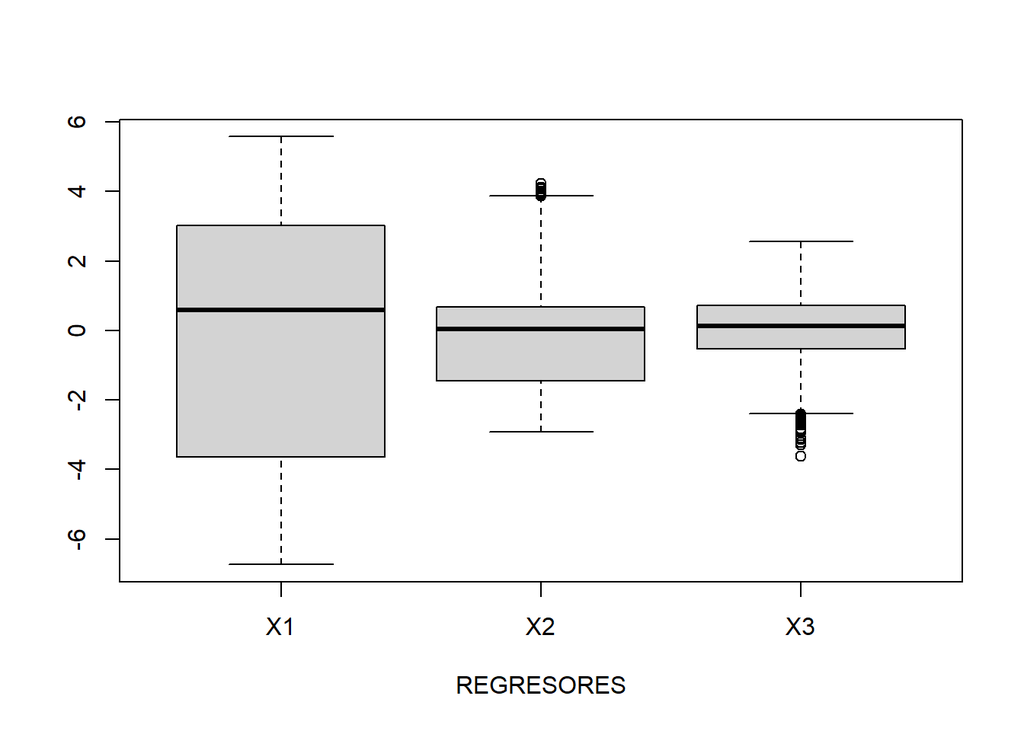

```r
boxplot(datos_regresion[, c(1,2,3)], xlab = "REGRESORES")
```

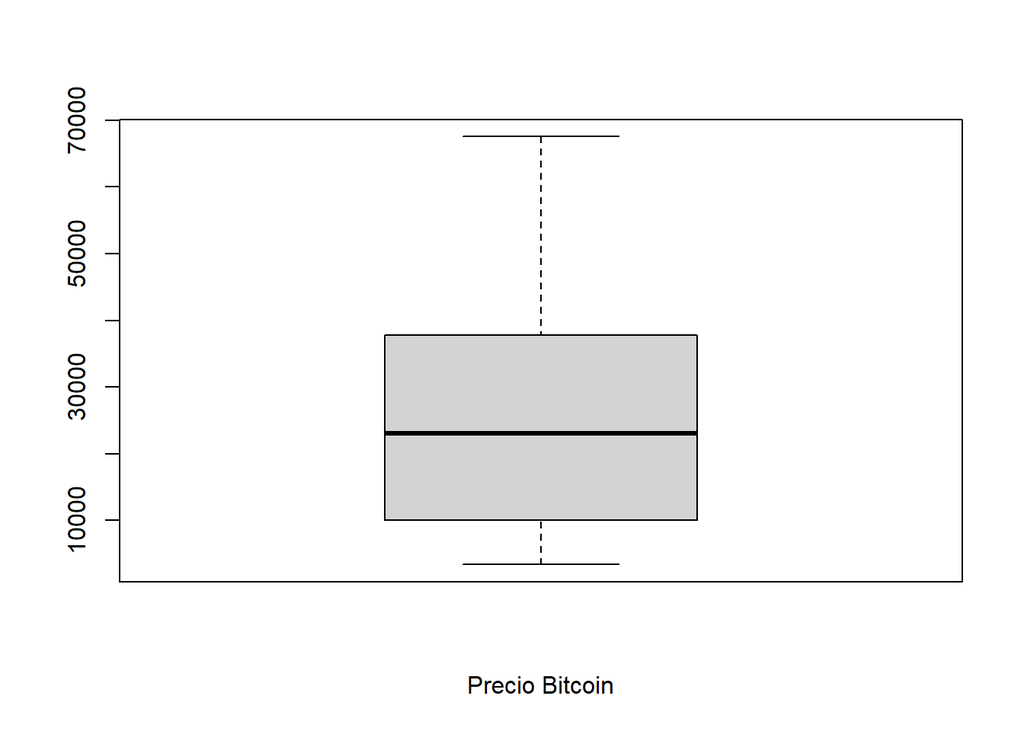

```r
#Podemos realizar cada boxplot por separado para visualizarlo mejor.
#Para la variable RESPUESTA tenemos:
boxplot(precio_bitcoin, xlab='Precio Bitcoin')
```

```r
# PARECE QUE NO SE OBSERVA NINGÚN VALOR ATÍPICO EN LA VARIABLE RESPUESTA, SI PODEMOS OBSERVAR LA DIFERENCIA DE ESCALA ENTRE LOS REGRESORES Y LA VARIABLE RESPUESTA Y ADEMÁS QUE ALGUNOS REGRESORES SI CONTIENEN DATOS ATÍPICOS
```

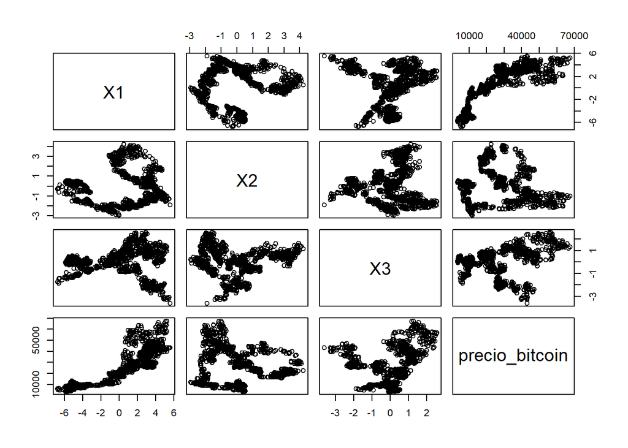

```r
# NUBE DE PUNTOS ENTRE LOS REGRESORES Y LA VARIABLE RESPUESTA:
plot(datos_regresion)
```

```r
#Pruebas de normalidad de la variable RESPUESTA:
shapiro.test(precio_bitcoin)
```

```
##
##  Shapiro-Wilk normality test
##
## data:  precio_bitcoin
## W = 0.93107, p-value < 2.2e-16
```

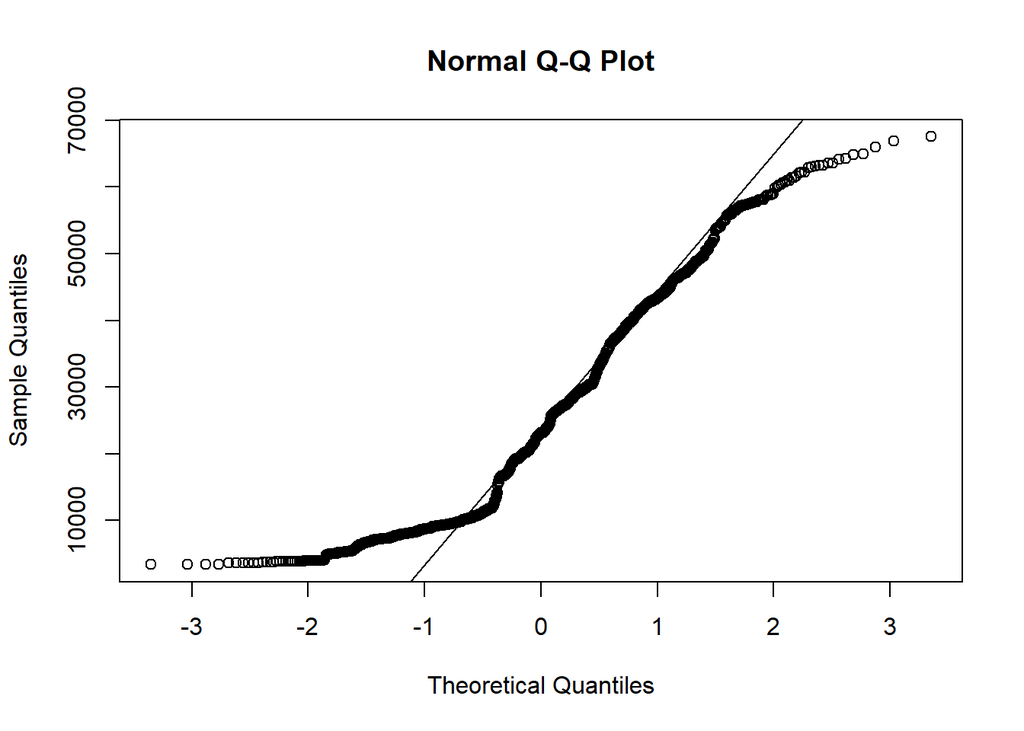

```r
qqnorm(precio_bitcoin)
qqline(precio_bitcoin)
```

```r
# SE VE COMPROMETIDA LA NORMALIDAD DE LA VARIABLE RESPUESTA VEAMOS SI PODEMOS REALIZAR ALGUNA TRANSFORMACIÓN:

# EN EL GRÁFICO DE CUANTILES PODEMOS OBSERVAR CURVATURAS A LA IZQUIERDA Y A LA DERECHA, ESTO NOS INDICA LA NO NORMALIDAD DE LA VARIABLE.
```

PROBEMOS CON UNA TRANSFORMACIÓN DE LA FAMILIA BOX-COX:

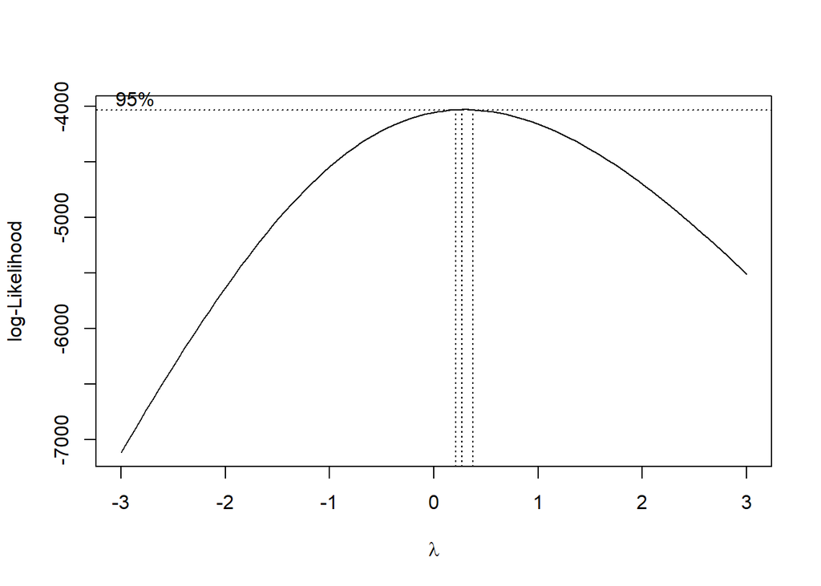

```r
library(MASS)
boxcox(lm(precio_bitcoin ~ 1, data = datos_regresion), lambda = seq(-3, 3, 1/10))
```

```r
boxcox(lm(precio_bitcoin ~ 1, data = datos_regresion), lambda = seq(-3, 3, 1/10), plotit = FALSE)
```

```
## $x
##  [1] -3.0 -2.9 -2.8 -2.7 -2.6 -2.5 -2.4 -2.3 -2.2 -2.1 -2.0 -1.9 -1.8 -1.7 -1.6
## [16] -1.5 -1.4 -1.3 -1.2 -1.1 -1.0 -0.9 -0.8 -0.7 -0.6 -0.5 -0.4 -0.3 -0.2 -0.1
## [31]  0.0  0.1  0.2  0.3  0.4  0.5  0.6  0.7  0.8  0.9  1.0  1.1  1.2  1.3  1.4
## [46]  1.5  1.6  1.7  1.8  1.9  2.0  2.1  2.2  2.3  2.4  2.5  2.6  2.7  2.8  2.9
## [61]  3.0
##
## $y
##  [1] -7117.521 -6957.903 -6800.313 -6644.904 -6491.839 -6341.297 -6193.471
##  [8] -6048.567 -5906.808 -5768.428 -5633.676 -5502.810 -5376.096 -5253.809
## [15] -5136.220 -5023.602 -4916.217 -4814.317 -4718.132 -4627.873 -4543.720
## [22] -4465.825 -4394.306 -4329.246 -4270.692 -4218.661 -4173.136 -4134.072
## [29] -4101.399 -4075.022 -4054.832 -4040.698 -4032.480 -4030.025 -4033.171
## [36] -4041.749 -4055.584 -4074.496 -4098.304 -4126.821 -4159.861 -4197.238
## [43] -4238.767 -4284.264 -4333.548 -4386.444 -4442.778 -4502.384 -4565.102
## [50] -4630.775 -4699.256 -4770.404 -4844.084 -4920.167 -4998.533 -5079.068
## [57] -5161.663 -5246.216 -5332.633 -5420.822 -5510.699
```

```r
# PODEMOS OBSERVAR QUE PUEDE SER UNA TRANFORMACIÓN ADECUADA EL ELEVAR A 0.3 LA VARIABLE RESPUESTA YA QUE ES EL PUNTO DE MÁXIMA VEROSIMILITUD
bitcoin_trans <- datos_regresion$precio_bitcoin ^ 0.3
shapiro.test(bitcoin_trans)
```

```
##
##  Shapiro-Wilk normality test
##
## data:  bitcoin_trans
## W = 0.95832, p-value < 2.2e-16
```

```r
# NO HE CONSEGUIDO CON LA TRANSFORMACIÓN DE LOS DATOS QUE LA VARIABLE RESPUESTA SIGA UNA DISTRIBUCIÓN NORMAL, POR TANTO, NUESTRO MODELO PUEDE SER QUE DE ALGUNOS VALORES SESGADOS Y OTROS ALGO INEXACTOS PERO VEAMOS COMO AVANZA LA CONSTRUCCIÓN DEL MODELO
```

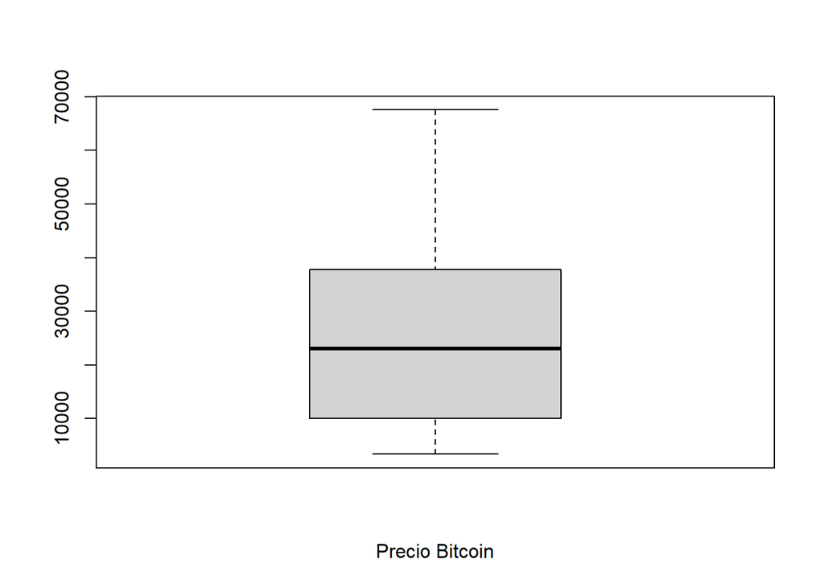

```r
boxplot(precio_bitcoin, xlab='Precio Bitcoin')
```

```r
# COMO HEMOS OBSERVADO ANTERIORMENTE EN LAS GRÁFICAS DE CAJA DE BIGOTES Y RECORDANDO QUE A LA HORA DE OBTENER LAS COMPONENTES PRINCIPALES, HEMOS USADO LA MATRIZ DE CORRELACIONES, NUESTROS DATOS SE ENCUENTRAN TIPIFICADOS, POR TANTO, DEBEMOS TIPIFICAR TAMBIÉN LA VARIABLE RESPUESTA PARA QUE SE ENCUENTRE EN LA MISMA ESCALA Y ASÍ NO TENER PROBLEMAS CON LAS MAGNITUDES:
datos_regresion$precio_bitcoin <- ((precio_bitcoin - mean(precio_bitcoin)) / sd(precio_bitcoin))
precio_bitcoin <- ((precio_bitcoin - mean(precio_bitcoin)) / sd(precio_bitcoin))
```

VAMOS A CONSTRUIR EL MODELO EMPLEANDO EL ALGORITMO DE ENTRENAMIENTO DE DESCENSO DE GRADIENTE, UTILIZAREMOS UN BUCLE CON EL QUE IREMOS ACTUALIZANDO LOS COEFICIENTES(TETHAS) CON EL FIN DE IR REDUCIENDO EL VALOR DE LA FUNCIÓN DE COSTO, UTILIZAREMOS UN 80% DE LOS DATOS PARA ENTRENAR AL MODELO Y CON EL 20% RESTANTE EVALUAREMOS AL MODELO CON DATOS NUEVOS Y VEREMOS CUÁL ES SU CAPACIDAD PREDICTIVA Y DE GENERALIZACIÓN:

```r
# DIVIDIMOS DATASET EN CONJUNTO DE ENTRENAMIENTO Y CONJUNTO DE TEST:

set.seed(123)

indices_entrenamiento <- sample(1:nrow(datos_regresion), 0.8 * nrow(datos_regresion))

datos_entrenamiento <- datos_regresion[indices_entrenamiento, ]
datos_prueba <- datos_regresion[-indices_entrenamiento, ]

colnames(datos_entrenamiento)
```

```
## [1] "X1"             "X2"             "X3"             "precio_bitcoin"
```

```r
X0 <- rep(1, length(datos_entrenamiento$X1))
n <- length(datos_entrenamiento$X1)


#Número regresores:
k <- 3

#Metemos los datos muestrales en una matriz de diseño M:
M <- matrix(1, nrow = n, ncol = k + 1)
M[,2] <- datos_entrenamiento$X1
M[,3] <- datos_entrenamiento$X2
M[,4] <- datos_entrenamiento$X3


#Definimos función costo usando la matriz de diseño M:
h_RLM <- function(theta, x) {
  sum(theta*x)
  }

J_RLM <- function(theta, M) {
  0.5*sum((M %*% theta - datos_entrenamiento$precio_bitcoin)^2)/n
}

#Fijamos número de iteraciones, learning rate y valores iniciales:

m_RLM <- 25 # ITERACIONES
alfa_RLM <- 0.1 # TASA DE APRENDIZAJE
theta_RLM <- c(1, 1, 1, 1) # INICIALIZACIÓN DE LOS COEFICIENTES
# DESPUÉS DE REALIZAR DISTINTAS INICIALIZACIONES ME QUEDO CON ESTA QUE NOS PROPORCIONA EL MEJOR ENTRENAMIENTO


J2_RLM <- array() #Vector con actualizaciones de la función costo en cada iteración
hv_RLM <- array() #Vector con actualizaciones de los valores ajustados en cada iteración
Z2_RLM <- matrix(NA, nrow = m_RLM + 1, ncol = k + 1)

#Matriz con actualizaciones de los theta en cada iteración
J2_RLM[1] <- J_RLM(theta_RLM, M)
Z2_RLM[1,] <-theta_RLM
```

ALGORITMO DONDE VAMOS ACTUALIZANDO LOS COEFICIENTES DE MANERA QUE SE VA REDUCIENDO LA FUNCIÓN DE COSTO, ENTRENAMIENTO DEL MODELO:

```r
for (i in 1:m_RLM) {
hv_RLM <- M %*% theta_RLM
theta_RLM <- theta_RLM - (alfa_RLM/n) * t(M) %*% (hv_RLM - datos_entrenamiento$precio_bitcoin)

# EN CADA ITERACIÓN INCLUIMOS EN EL ARRAY J2_RLM Y EN LA MATRIZ Z2_RLMEL VALOR DE LA FUNCIÓN DE COSTO Y ACTUALIZAMOS CON EL VALOR DE LOS NUEVOS COEFICIENTES RESPECTIVAMENTE:
J2_RLM[i + 1] <-J_RLM(theta_RLM, M)
Z2_RLM[i + 1,] <- theta_RLM
}
#Guardamos los valores de los thetas y de la función de costo en  cada iteración en un dataframe:
resultados <- data.frame(Z2_RLM, J2_RLM)
colnames(resultados) <- c("theta0", "theta1", "theta2","theta3", "costo")

# COEFICIENTES Y COSTO EN CADA ITERACIÓN:
View(resultados)
```

COEFICIENTES ÓPTIMOS SEGÚN NUESTRO ENTRENAMIENTO MEDIANTE DESCENSO DE GRADIENTE:

```r
coef_optimos_GD <- Z2_RLM[m_RLM + 1, ]
coef_optimos_GD
```

```
## [1]  0.07635477  0.24937314 -0.09135765  0.26064886
```

COMPAREMOS LOS RESULTADOS QUE NOS PROPORCIONA EL ALGORITMO DE ENTRENAMIENTO DE GD CON EL MÉTODO lm() QUE NOS PROPORCIONA R:

```r
modelo_prediccion <- lm(precio_bitcoin ~ X1 + X2 + X3, data = datos_entrenamiento)
```

COEFICIENTES ÓPTIMOS SEGÚN EL MÉTODO lm():

```r
modelo_prediccion$coefficients
```

```
##  (Intercept)           X1           X2           X3
##  0.008540132  0.249457255 -0.090409442  0.238392399
```

Valor de costo óptimo según GD:

```r
2*J_RLM(Z2_RLM[m_RLM + 1,], M)
```

```
## [1] 0.174523
```

VEAMOS LA GRÁFICA CON LA CONVERGENCIA DE LA FUNCIÓN DE COSTO:

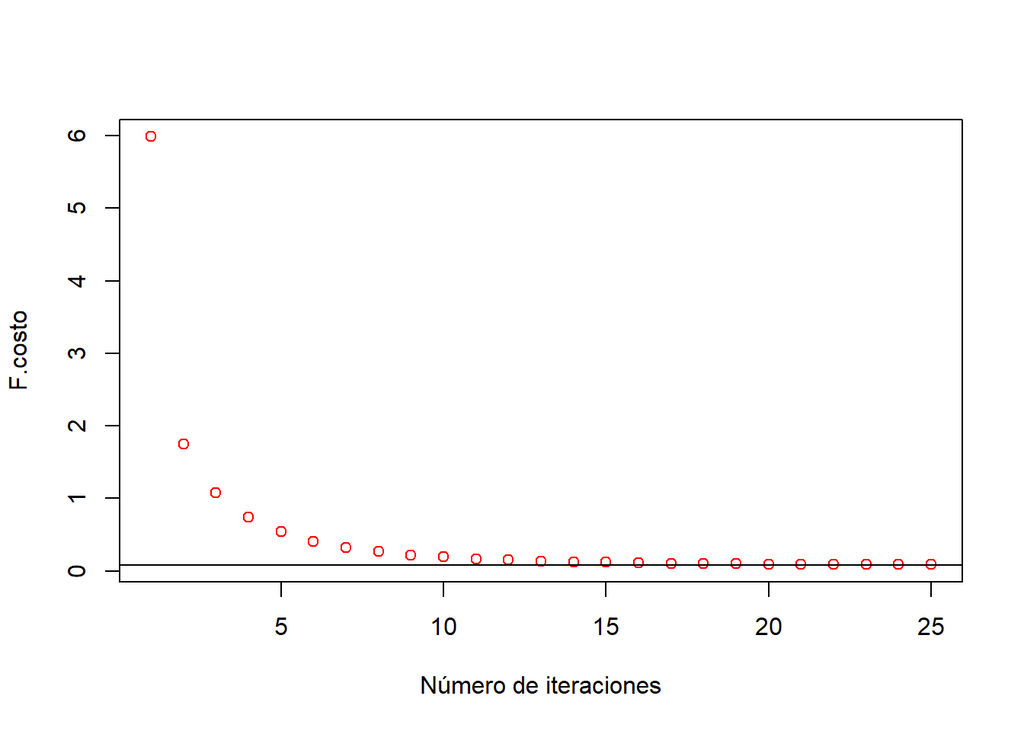

```r
Jm <-1:m_RLM
for (i in 1:m_RLM) {
Jm[i] <- J_RLM(Z2_RLM[i, ], M)
}
min_RLM <-J_RLM(modelo_prediccion$coefficients, M)
plot(Jm[1:m_RLM], col = 'red', xlab = 'Número de iteraciones', ylab = 'F.costo')
abline(h = min_RLM)
```

Valor de costo óptimo según el método lm():

```r
MSE <- mean(modelo_prediccion$residuals^2)
print("Valor de costo óptimo según lm():")
```

```
## [1] "Valor de costo óptimo según lm():"
```

```r
MSE
```

```
## [1] 0.1692342
```

# EVALUACIÓN DEL MODELO DE PREDICCIÓN: HAREMOS UN RESUMEN DEL MODELO CONSTRUIDO Y VAMOS A EMPLEAR EL CONJUNTO DE TEST PARA REALIZAR PREDICCIONES Y VER COMO PREDICE EL MODELO CON DATOS NUEVOS:

```r
summary(modelo_prediccion)
```

```
##
## Call:
## lm(formula = precio_bitcoin ~ X1 + X2 + X3, data = datos_entrenamiento)
##
## Residuals:
##      Min       1Q   Median       3Q      Max
## -1.16302 -0.24127 -0.00528  0.24190  1.30015
##
## Coefficients:
##              Estimate Std. Error t value Pr(>|t|)
## (Intercept)  0.008540   0.013086   0.653    0.514
## X1           0.249457   0.003808  65.514   <2e-16 ***
## X2          -0.090409   0.007927 -11.405   <2e-16 ***
## X3           0.238392   0.011592  20.565   <2e-16 ***
## ---
## Signif. codes:  0 '***' 0.001 '**' 0.01 '*' 0.05 '.' 0.1 ' ' 1
##
## Residual standard error: 0.4122 on 989 degrees of freedom
## Multiple R-squared:  0.8322, Adjusted R-squared:  0.8317
## F-statistic:  1636 on 3 and 989 DF,  p-value: < 2.2e-16
```

```r
# OBSERVANDO EL COEFICIENTE DE DETERMINACIÓN R^2 DEL MODELO:
 round(summary(modelo_prediccion)$r.squared, 4)
```

```
## [1] 0.8322
```

```r
# Los modelos de regresión obtenidos explican aproximadamente el 83.22% de la variabilidad del precio de Bitcoin:

100*summary(modelo_prediccion)$r.squared #%
```

```
## [1] 83.22494
```

```r
print('Intervalos de confianza al 95% para los coeficientes del modelo de predicción:')
```

```
## [1] "Intervalos de confianza al 95% para los coeficientes del modelo de predicción:"
```

```r
confint(modelo_prediccion, level=0.95)
```

```
##                   2.5 %      97.5 %
## (Intercept) -0.01713934  0.03421960
## X1           0.24198515  0.25692936
## X2          -0.10596566 -0.07485323
## X3           0.21564486  0.26113994
```

```r
# Cualquier modelo teórico con coeficientes dentro de los intervalos obtenidos serían también válidos teniendo en cuenta nuestros datos muestrales.
```

# PREDICCIONES CON DATOS NUEVOS(CONJUNTO DE TEST):

```r
 # PREDICCIÓN VALOR PROMEDIO:
P_promedio <- predict(modelo_prediccion, newdata = datos_prueba[,c(1,2,3)], interval = "confidence", level = 0.95) * dtipica_bitcoin + media_bitcoin
```

```r
# PREDICCIÓN DEL VALOR EXACTO PARA ESAS CARACTERÍSTICAS EN CONCRETO:
P_exacta <- predict(modelo_prediccion, newdata = datos_prueba[,c(1,2,3)], interval = "prediction", level = 0.95) * dtipica_bitcoin + media_bitcoin
```

POR EJEMPLO: Aquí mostramos la predicción del valor promedio y del valor exacto de Bitcoin con una confianza del 95% PARA 4 valores distintos: .

```r
for (i in c(1, 34, 98, 137)) {
  # Imprimir las filas correspondientes de datos_prueba, P_promedio y P_exacta
  print(paste("Predicción", i))
  print(paste("Datos de prueba:", datos_prueba[i,c(1, 2, 3)]))
  print(paste("Predicción promedio:"))
  print(P_promedio[i,])
  print(paste("Predicción exacta:"))
  print(P_exacta[i,])
  print("--------------------")
}
```

```
## [1] "Predicción 1"
## [1] "Datos de prueba: 5.57815905624608"  "Datos de prueba: -1.89292979899243"
## [3] "Datos de prueba: -3.62614162175782"
## [1] "Predicción promedio:"
##      fit      lwr      upr
## 36570.35 34940.44 38200.26
## [1] "Predicción exacta:"
##      fit      lwr      upr
## 36570.35 23502.27 49638.43
## [1] "--------------------"
## [1] "Predicción 34"
## [1] "Datos de prueba: 3.93719455761302"   "Datos de prueba: 0.0132060424386057"
## [3] "Datos de prueba: -2.07670949609159"
## [1] "Predicción promedio:"
##      fit      lwr      upr
## 33167.22 32169.92 34164.53
## [1] "Predicción exacta:"
##      fit      lwr      upr
## 33167.22 20162.89 46171.56
## [1] "--------------------"
## [1] "Predicción 98"
## [1] "Datos de prueba: 3.25482443968981"  "Datos de prueba: 1.18836915180308"
## [3] "Datos de prueba: 0.602992486834343"
## [1] "Predicción promedio:"
##      fit      lwr      upr
## 38975.38 38306.97 39643.79
## [1] "Predicción exacta:"
##      fit      lwr      upr
## 38975.38 25992.13 51958.63
## [1] "--------------------"
## [1] "Predicción 137"
## [1] "Datos de prueba: 0.681004980866752" "Datos de prueba: -1.43127958846171"
## [3] "Datos de prueba: 1.70266769200005"
## [1] "Predicción promedio:"
##      fit      lwr      upr
## 36682.22 35855.08 37509.37
## [1] "Predicción exacta:"
##      fit      lwr      upr
## 36682.22 23689.83 49674.61
## [1] "--------------------"
```

# POR ÚLTIMO, REALIZAREMOS UNA SERIE DE TEST PARA VER SI PODEMOS VALIDAR EL MODELO:

```r
# 1) Hipótesis de Normalidad:
shapiro.test(modelo_prediccion$residuals)
```

```
##
##  Shapiro-Wilk normality test
##
## data:  modelo_prediccion$residuals
## W = 0.99309, p-value = 0.0001424
```

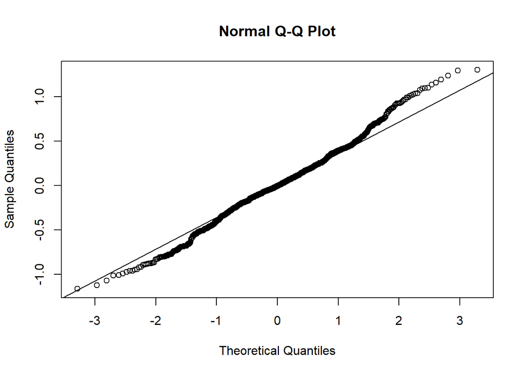

```r
qqnorm(modelo_prediccion$residuals)
qqline(modelo_prediccion$residuals)
```

```r
# PARECE QUE LOS RESIDUOS NO SIGUEN UNA NORMAL, PUEDE SER QUE NUESTRO MODELO ESTE ALGO SESGADO, POR TANTO, HAY QUE TENER EN CUENTA QUE LAS PREDICCIONES QUE HAGAMOS CON NUESTRO MODELO NO SERÁN TAN FIABLES Y ROBUSTAS QUE SI SI HUBIÉSEMOS CONSEGUIDO NORMALIDAD EN LOS RESIDUOS DEL MODELO.
```

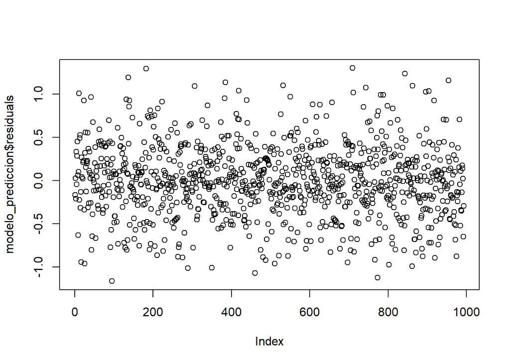

```r
# Aquí podemos observar los residuos de nuestro modelo(diferencia entre su predicción y el valor deseado para cada muestra)
plot(modelo_prediccion$residuals)
```

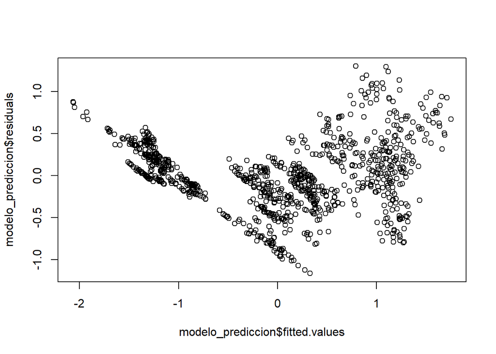

```r
# 2) Hipótesis de Homocedasticidad:
plot(modelo_prediccion$fitted.values, modelo_prediccion$residuals)
```